# working with tantale

### 1.3.2 count corrections

total correction count per genome (in this case, there is only 1 genome that has been corrected)

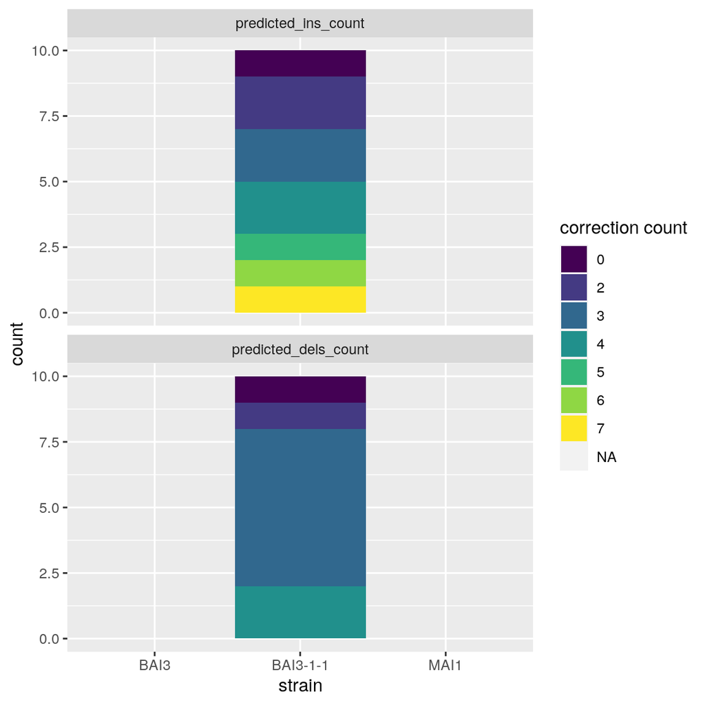

```r
ggplot(arrayRp_correction) +
  facet_wrap(vars(type), nrow = 2, scales = "fixed") +
  geom_bar(aes(x = strain, fill = factor(count))) +
  scale_fill_viridis_d() +
  guides(fill = guide_legend(title = "correction count"))
```

correction count per array per genome

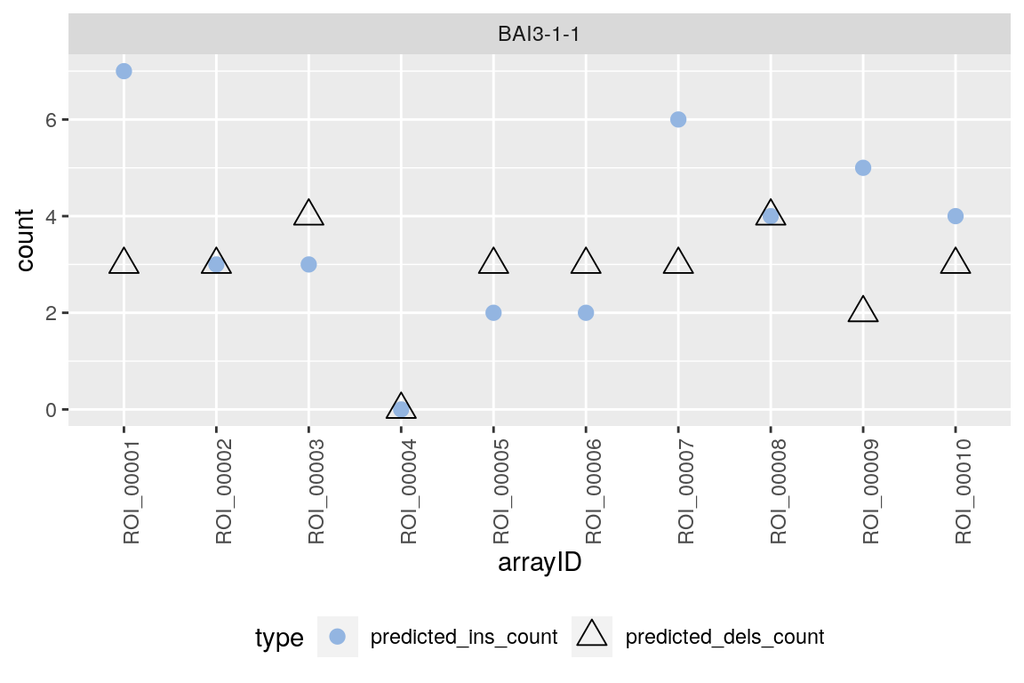

```r
ggplot(na.omit(arrayRp_correction), aes(x = arrayID, y = count, color = type, shape = type)) +
  facet_wrap(vars(strain), nrow = 2) +
  scale_shape_manual(values = c(20, 2)) +
  geom_point(size = 4) +
  scale_color_manual(values = c(sunset10[4], "black"))+
  theme(axis.text.x = element_text(angle = 90),
        legend.direction = "horizontal", legend.position = "bottom")
```

correction distribution per genome

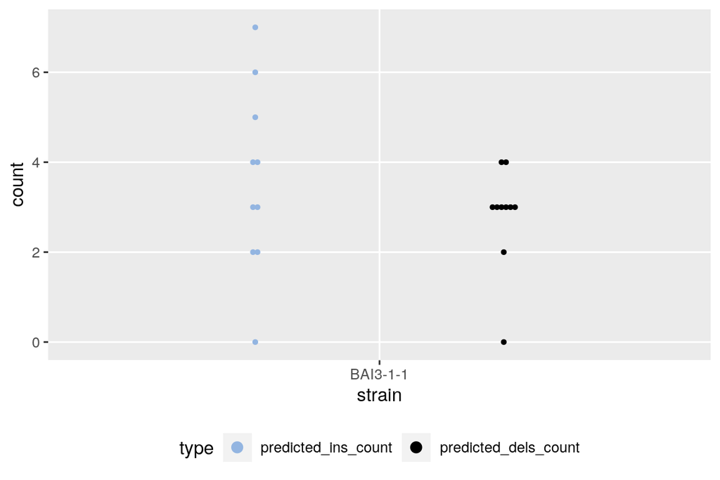

```r
ggplot(na.omit(arrayRp_correction), aes(x = strain, y = count)) +
  geom_dotplot(aes(fill = type, color = type), binaxis = "y", stackdir = "center", position = "dodge", binwidth = 1/10) +
  scale_fill_manual(values = c(sunset10[4], "black")) +
  scale_color_manual(values = c(sunset10[4], "black")) +
  theme(legend.direction = "horizontal", legend.position = "bottom",
        panel.grid.minor.y = element_blank())
```

### 1.3.3 count domain codon

Another report that we can reveal is “hitsReport.tsv”, which contains results of HMMer.

```r
hitsReport_files <- dir(telltale2_outdir, "hitsReport.tsv", recursive = T, full.names = T)

hitsReport <- data.frame()
for (f in hitsReport_files) {
  a <- read.table(f, sep = "\t", stringsAsFactors = F, header = T)
  a$strain <- gsub("\\_.+", "", basename(dirname(f)))
  hitsReport <- rbind(hitsReport, a)
}
hitsReport$query_name <- factor(hitsReport$query_name, levels = c("TALE_N-terminus_CDS_aligned_curated", "TALE_repeat_CDS_aligned_curated", "TALE_C-terminus_CDS_aligned_curated_long"), ordered = F)
```

information in the hitsReport

```r
colnames(hitsReport)
#>>  [1] "arrayID"          "seqnames"         "start"            "end"
#>>  [5] "width"            "strand"           "nhmmerHitID"      "query_name"
#>>  [9] "hitID"            "seq"              "codon_count"      "frameshift_count"
#>> [13] "strain"
```

We could see the length distribution of each Tal protein domain (`query_name`) predicted by HMMer.

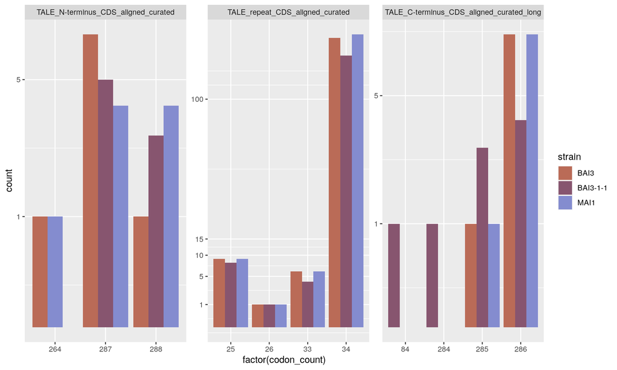

```r
ggplot(hitsReport) +
  facet_wrap(vars(query_name), scales = "free", nrow = 1) +
  geom_bar(aes(x = factor(codon_count), fill = strain), stat = "count", position = position_dodge(preserve = "single")) +
  scale_fill_manual(values = sunset10) +
  scale_y_sqrt(breaks = c(0, 1, 5, 10, 15, 100, 200, 350))
```

It seems that BAI3-1-1 has 1 Tal truncated at C-terminus caused by artifactual indels. But this is just the “raw” result of Tal motif detection.

Now we have a look at “domainsReport.tsv”, a similar report as “hitsReport.tsv” except that it contains the information of Tal domains predicted by AnnoTALE after correction, , so that we can make comparision and infer the impact of correction in the protein sequences.

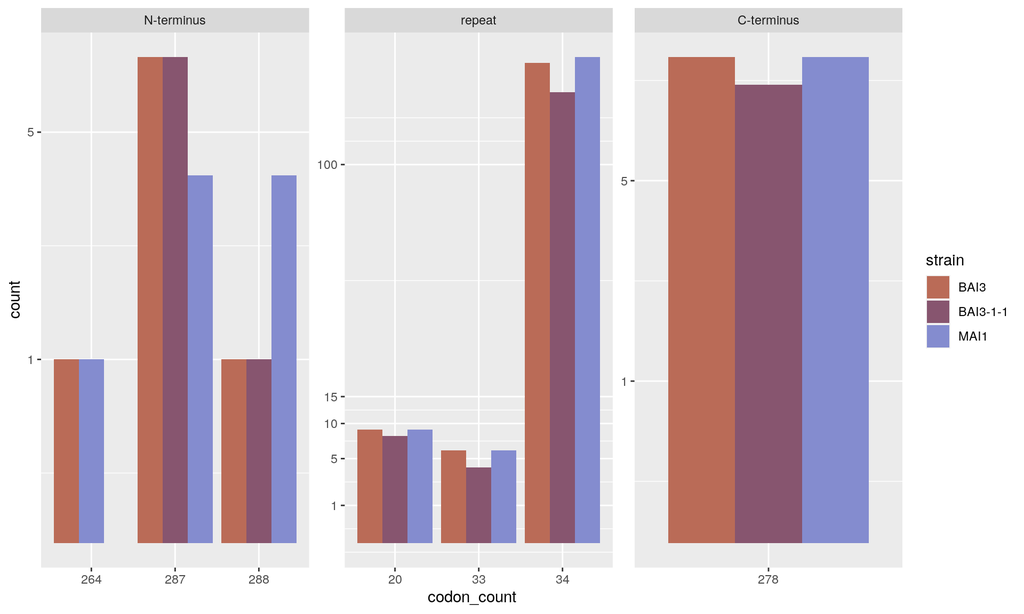

```r
domainsReport_file <- dir(telltale2_outdir, "domainsReport.tsv", recursive = T, full.names = T)

domainsReport <- data.frame()
for (f in domainsReport_file) {
  a <- read.table(f, sep = "\t", stringsAsFactors = F, header = T)
  a$strain <- gsub("\\_.+", "", basename(dirname(f)))
  domainsReport <- rbind(domainsReport, a)
}

domainsReport$query_name <- factor(domainsReport$query_name, levels = c("N-terminus", "repeat", "C-terminus"))
domainsReport$codon_count <- as.factor(domainsReport$codon_count)

ggplot(domainsReport) +
  facet_wrap(vars(query_name), scales = "free", nrow = 1) +
  geom_bar(aes(x = codon_count, fill = strain), stat = "count", position = position_dodge(preserve = "single")) +
  scale_fill_manual(values = sunset10) +
  scale_y_sqrt(breaks = c(0, 1, 5, 10, 15, 100, 200, 350))
```

Firstly, the domain detection of AnnoTALE is different from HMMer at some amino acids.  
Secondly, the truncated C-terminus of BAI3-1-1 (84 aa) has been corrected and has the same length as its counterparts.

# 2 classify TAL groups

To classify Tal groups, we use function `runDistal()` to run the tool DisTal that outputs similarity between Tals and similarity between repeats, then the Tals similarity can be taken as input of `groupTales()` for clustering groups, and the repeats similarity can be used for plotting multiple alignment of Tals within group.

## 2.1 run DisTal

We run DisTal for all the putative TAL ORFs (from `telltale2` output).

```r
distal_telltale <- file.path(outdir, "distal")
dir.create(distal_telltale, showWarnings = F)


telltale2_cds <- file.path(distal_telltale, "cds.fasta")
unlink(telltale2_cds)

distal_telltale_input <- list.files(telltale2_outdir, "putativeTalOrf.fasta", recursive = T, full.names = T)
distal_telltale_input <- distal_telltale_input[!grepl("temp_annotale", distal_telltale_input, fixed = T)]

for (input in distal_telltale_input) {
  id <- gsub("\\_.+", "", basename(dirname(input)))
  seqs <- readBStringSet(input, seek.first.rec = T)
  names(seqs) <- paste0(id, "_", names(seqs))
  names(seqs) <- stringr::str_trim(names(seqs))
  seqs <- seqs[width(seqs) != 0]
  writeXStringSet(seqs, telltale2_cds, append = T)
}

# run DisTal
distal_output <- runDistal(telltale2_cds, outdir = distal_telltale, overwrite = F)
```

## 2.2 classify TAL groups

```r
taleGroups <- groupTales(distal_output$tal.similar, k_test = 5:15, k = "auto")
#>> The number of groups is automatically decided based on the silhoutte value: 9
```

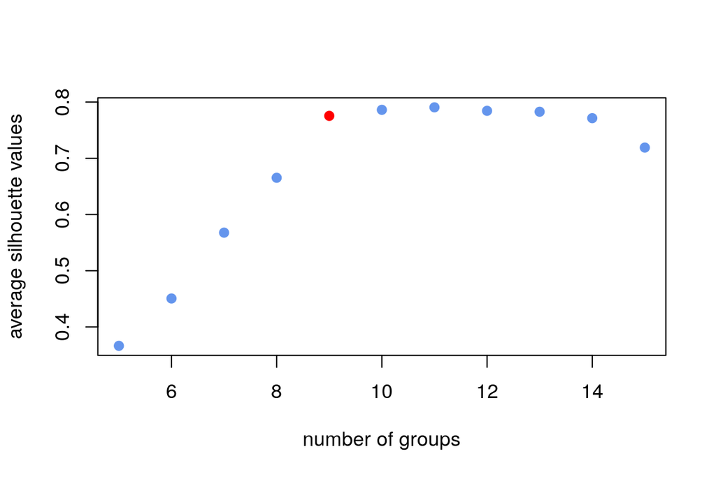

Based on the silhoutte values, `groupTales()` will take the value at the elbow of the curve. In this case it picked k = 9, and it makes sense as we already know that the each of the gold genomes have 9 Tals.

### 2.2.1 msa with similarity

We can make MSA of repeatID sequence or RVD sequence with the function `buildRepeatMsa()`, however it make more sense to align repeat than RVD. For mafft, the combo of gap opening score = 0 and gap extending score = 5 creates better alignment than default values.

```r
repeatVectors <- distal_output$coded.repeats.str
repeatSim <- distal_output$repeat.similarity
repeatMsaByGroup_withSim <- lapply(sort(unique(taleGroups$group)), function(G) {
  repeatVectorsForGroup <- repeatVectors[taleGroups$name[taleGroups$group == G]]
  if (length(repeatVectorsForGroup) < 2) {
    msa <- as.matrix(as.data.frame(repeatVectorsForGroup))
    msa <- matrix(msa, nrow = 1)
    rownames(msa) <- colnames(as.data.frame(repeatVectorsForGroup))
    colnames(msa) <- 1:length(msa)
    return(msa)
    next()
  }
  repeatMsa <- buildRepeatMsa(inputSeqs = repeatVectorsForGroup, distalRepeatSims = repeatSim, mafftOpts = "--globalpair --weighti 1 --maxiterate 1000 --reorder --op 0 --ep 5 --thread 8")
  }
)
```

#### 2.2.1.1 msa of repeat similarity

For this type of plot, we need to map repeatID to RVD with `getRepeat2RvdMapping()`, then convert repeat MSA to RVD MSA by `convertRepeat2RvdAlign`. We should use the converting function rather than using `buildRepeatMsa()` to creat MSA of RVD because there will be disagreement between them.

```r
rvdSeqs_fasta <- list.files(telltale2_outdir, "rvdSequences.fas", recursive = T, full.names = T)

telltale2_rvd <- file.path(distal_telltale, "rvd.fasta")
unlink(telltale2_rvd)

# rename of RVD sequences to distinguish sequences between different strains
for (input in rvdSeqs_fasta) {
  id <- gsub("\\_.+", "", basename(dirname(input)))
  seqs <- readBStringSet(input, seek.first.rec = T)
  names(seqs) <- paste0(id, "_", names(seqs))
  names(seqs) <- stringr::str_trim(names(seqs))
  seqs <- seqs[width(seqs) != 0]
  writeXStringSet(seqs, telltale2_rvd, append = T)
}

rvdVectors <- readBStringSet(telltale2_rvd)
rvdVectors <- sapply(rvdVectors, function(r) strsplit(toString(r), split = "-"))
repeatVectors <- distal_output$coded.repeats.str

# map repeatID to RVD
rep2rvd <- getRepeat2RvdMapping(talesRepeatVectors = repeatVectors, talesRvdVectors = rvdVectors)
datatable(rep2rvd, options = list(pageLength = 5))
```

|  | repeatID | RVD |
| --- | --- | --- |
| 1 | 0 | CTERM |
| 2 | 1 | CTERM |
| 3 | 10 | CTERM |
| 4 | 100 | NTERM |
| 5 | 101 | NTERM |
| 6 | 102 | NTERM |
| 7 | 103 | NTERM |
| 8 | 104 | NTERM |
| 9 | 105 | NTERM |
| 10 | 106 | NTERM |

[output cut: 103 more lines]

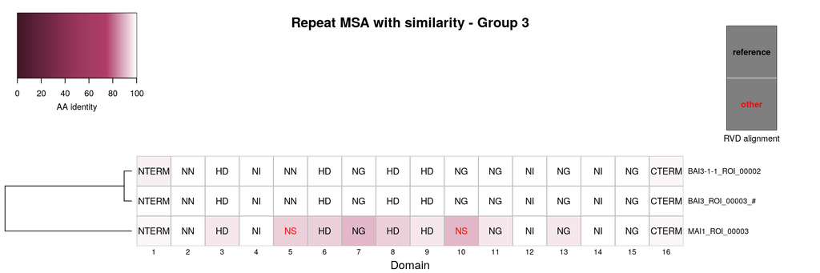

```r
# convert repeat MSA to RVD MSA
repeatMSA <- repeatMsaByGroup_withSim[[3]]
rvdMSA <-  convertRepeat2RvdAlign(repeatAlign = repeatMSA, repeat2RvdMapping = rep2rvd)

# plot MSA
tantale::heatmap_msa(talsim = distal_output$tal.similarity, repeatAlign = repeatMSA, repeatSim = distal_output$repeat.similarity, rvdAlign = rvdMSA, plot.type = "repeat.similarity", main = "Repeat MSA with similarity - Group 3")
```

#### 2.2.1.2 msa of repeat cluster ID

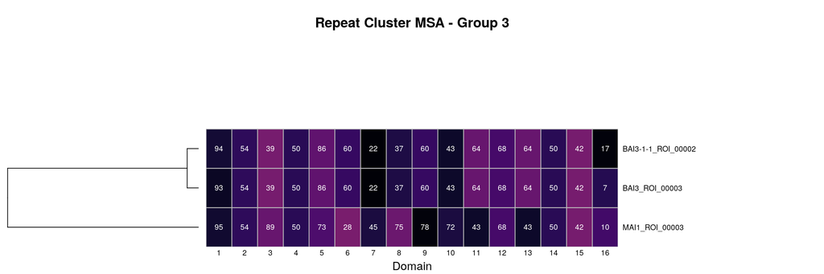

```r
tantale::heatmap_msa(talsim = distal_output$tal.similarity, repeatAlign = repeatMSA, repeatSim = distal_output$repeat.similarity, plot.type = "repeat.clusters", main = "Repeat Cluster MSA - Group 3")
```

#### 2.2.1.3 msa of repeat ID with RVD labeled

For this plot, we also use the RVD MSA converted from repeat MSA.

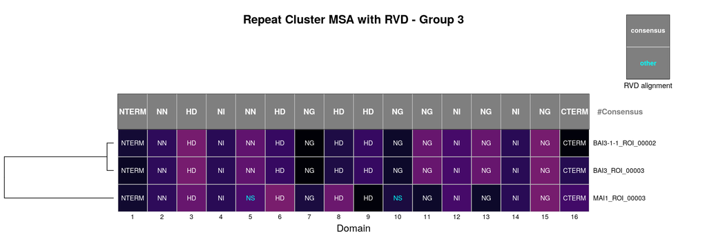

```r
rvdMSA <-  convertRepeat2RvdAlign(repeatAlign = repeatMSA, repeat2RvdMapping = rep2rvd)
tantale::heatmap_msa(talsim = distal_output$tal.similarity, repeatAlign = repeatMSA, repeatSim = distal_output$repeat.similarity,  rvdAlign = rvdMSA, plot.type = "repeat.clusters.with.rvd", main = "Repeat Cluster MSA with RVD - Group 3", consensusSeq = TRUE)
```

# 3 overview of talomes

With the Tal classification result and RVD sequences, we can represent RVD sequence variants of all the strains for each Tal group as an example below.

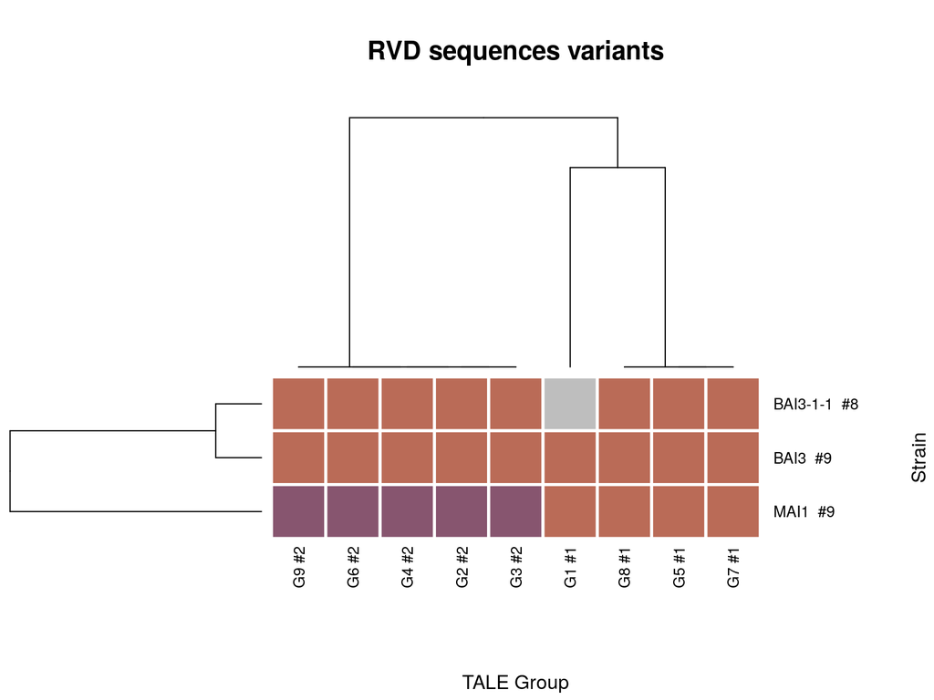

```r
tale_annotation <- merge(taleGroups,
      data.frame("name" = names(rvdVectors), "rvdseq" = sapply(rvdVectors, function(i) paste(i, collapse = "-")), stringsAsFactors = FALSE))
tale_annotation$strain <- gsub("\\_.+", "", tale_annotation$name)

heatmap_talomes(tale_annotation, col = "group", row = "strain", value = "rvdseq", mapcol = sunset10)
```

# 4 predict target

We wrap Talvez and Preditale tools in 2 functions, `talvez()` and `preditale()`, that take the same types of RVD sequences and promoter DNA sequences as inputs and output a data frame containing predictions.

We need to concatenate all RVD sequences from 3 `telltale2` outputs and remove NTERM and CTERM markers.

```r
## rvd sequences from telltale2 output
rvdSeqs_tt <-  readBStringSet(telltale2_rvd)
rvdSeqs_tt <- gsub("\\-{0,1}\\w{5}\\-{0,1}", "",rvdSeqs_tt) %>% BStringSet() # remove NTERM and CTERM
predict_input <- file.path(outdir, "rvd_to_predict.fasta")
writeXStringSet(rvdSeqs_tt, predict_input)


## promoter sequences
rvdSeqsXstrings <-  predict_input
subjDnaSeqFile <-  system.file("extdata", "cladeIII_sweet_promoters.fasta", package = "tantale", mustWork = T)
readBStringSet(subjDnaSeqFile) %>% names
#>> [1] "SWEET11p_IR64_Sense"             "SWEET11p_BT07_Sense"
#>> [3] "SWEET11p_93-11_Sense"            "SWEET11p_Nipponbare_Sense"
#>> [5] "SWEET13p_BT7_Sense"              "SWEET13p_IR24_Sense"
#>> [7] "SWEET13p_Nipponbare_Sense"       "SWEET14p_BT07_Sense"
#>> [9] "SWEET14p_Kitaake_or_Nip_?_Sense"
```

## 4.1 talvez

The output of `talvez()` contains the position, score and rank of each prediction.

```r
talvezPreds <- talvez(rvdSeqs = rvdSeqsXstrings, subjDnaSeqFile = subjDnaSeqFile, optParam = "-t 0 -l 19")
datatable(talvezPreds, options = list(pageLength = 1))
```

|  | taleId | rvds | subjSeqId | score | strand | start | end | ebeSeq | rank |
| --- | --- | --- | --- | --- | --- | --- | --- | --- | --- |
| 1 | BAI3-1-1_ROI_00001 | NN-NG-NN-HD-HD-NI-N*-NG-HD-NI-NG-NN-HD-NI-NG-NI-NG-NN-NG-HD-NI-NI-NG-HD-NN-NG | SWEET11p_93-11_Sense | 10.012 | - | 980 | 1006 | TGTACCACTAACACCAACATGCCAAGA | 1 |
| 2 | BAI3-1-1_ROI_00001 | NN-NG-NN-HD-HD-NI-N*-NG-HD-NI-NG-NN-HD-NI-NG-NI-NG-NN-NG-HD-NI-NI-NG-HD-NN-NG | SWEET14p_Kitaake_or_Nip_?_Sense | 6.347 | - | 160 | 186 | TGTTTCCTTCATAACTCTGTCCTCAAT | 2 |
| 3 | BAI3-1-1_ROI_00002 | NN-HD-NI-NN-HD-NG-HD-HD-NG-NG-NI-NG-NI-NG | SWEET11p_93-11_Sense | 6.959 | + | 1395 | 1409 | TGTACATCCTTCTAC | 1 |
| 4 | BAI3-1-1_ROI_00002 | NN-HD-NI-NN-HD-NG-HD-HD-NG-NG-NI-NG-NI-NG | SWEET11p_93-11_Sense | 6.659 | + | 1489 | 1503 | TCCAGCTCTCCAAAT | 2 |
| 5 | BAI3-1-1_ROI_00002 | NN-HD-NI-NN-HD-NG-HD-HD-NG-NG-NI-NG-NI-NG | SWEET11p_IR64_Sense | 6.531 | + | 135 | 149 | TGCATCTCCCCCTAC | 3 |
| 6 | BAI3-1-1_ROI_00002 | NN-HD-NI-NN-HD-NG-HD-HD-NG-NG-NI-NG-NI-NG | SWEET11p_BT07_Sense | 6.531 | + | 130 | 144 | TGCATCTCCCCCTAC | 4 |
| 7 | BAI3-1-1_ROI_00002 | NN-HD-NI-NN-HD-NG-HD-HD-NG-NG-NI-NG-NI-NG | SWEET11p_93-11_Sense | 6.531 | + | 1690 | 1704 | TGCATCTCCCCCTAC | 5 |
| 8 | BAI3-1-1_ROI_00002 | NN-HD-NI-NN-HD-NG-HD-HD-NG-NG-NI-NG-NI-NG | SWEET11p_Nipponbare_Sense | 6.531 | + | 128 | 142 | TGCATCTCCCCCTAC | 6 |
| 9 | BAI3-1-1_ROI_00003 | NN-ND-NN-NI-NK-NN-HD-NN-NG-NG-N*-HD-N*-HD-NI-NN-HD-NG-HD-HD-HD-NG-NN-HD-HD-NG | SWEET14p_BT07_Sense | 9.055 | - | 223 | 249 | TACAAGATAATCATCAGCACCCATGCA | 1 |
| 10 | BAI3-1-1_ROI_00003 | NN-ND-NN-NI-NK-NN-HD-NN-NG-NG-N*-HD-N*-HD-NI-NN-HD-NG-HD-HD-HD-NG-NN-HD-HD-NG | SWEET14p_Kitaake_or_Nip_?_Sense | 9.055 | - | 219 | 245 | TACAAGATAATCATCAGCACCCATGCA | 2 |

[output cut: 80 more lines]

Here is an example of summarizing prediction result with `heatmap.2()` (scores are display by color scale, black refers no prediction):

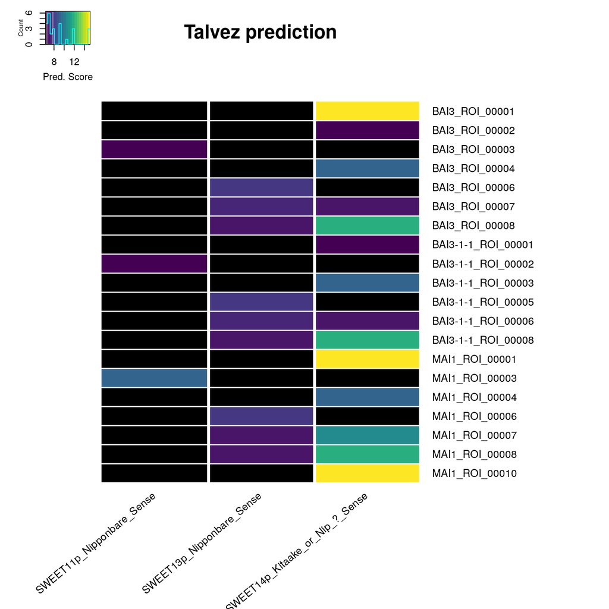

```r
talvezPreds$strain <- gsub("\\_.+", "", talvezPreds$taleId)
talvezPreds$group <- sapply(talvezPreds$taleId, function(id) {
  ifelse(id %in% taleGroups$name, taleGroups$group[taleGroups$name == id], NA)
}, USE.NAMES = F)

slctPromoters <- c("SWEET14p_Kitaake_or_Nip_?_Sense", "SWEET13p_Nipponbare_Sense", "SWEET11p_Nipponbare_Sense")
selectedPreds <- talvezPreds %>%
  dplyr::filter(subjSeqId %in% slctPromoters)

selectedPredsMat <- selectedPreds %>%
  reshape2::acast(taleId ~ subjSeqId, max, na.rm = TRUE, value.var = "score", fill = as.single(NA))

heatmap.2(selectedPredsMat,
                  col = viridis::viridis(20), #cm.colors(255),
                  sepwidth=c(0.02,0.02), sepcolor="white", colsep = 1:ncol(selectedPredsMat), rowsep = 1:nrow(selectedPredsMat),
                  trace="none",
                  margins = c(10, 15),
                  cexRow = 1,
                  cexCol = 1, srtCol = 40,
                  density.info= "histogram", key.xlab = "Pred. Score", key.title = NA,
                  lwid = c(1,5), lhei = c(1,5),
                  dendrogram = "none", Rowv = NULL, Colv = NULL,
                  na.color = "black",
                  main = "Talvez prediction"
                  )
```

To see how RVD sequences match a promoter region, we supply the prediction table and the promoter sequence with the genomic range to `plotTaleTargetPred()`:

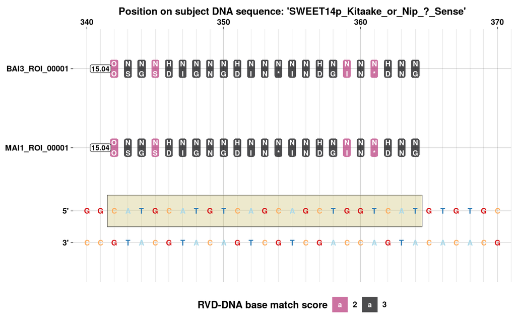

```r
grFilter <- "SWEET14p_Kitaake_or_Nip_?_Sense:340-370"
plotTaleTargetPred(predResults = selectedPreds, subjDnaSeqFile = subjDnaSeqFile, filterRange = grFilter)
#>> Registered S3 method overwritten by 'treeio':
#>>   method     from
#>>   root.phylo ape
```

## 4.2 preditale

With Preditale, we get similar data frame output but with p value additionally. Preditale takes a little bit longer than Talvez and may give some different predictions.

```r
preditalePreds <- preditale(rvdSeqs = rvdSeqsXstrings, subjDnaSeqFile = subjDnaSeqFile, outDir = NULL)
datatable(preditalePreds, options = list(pageLength = 1))
```

|  | subjSeqId | start | end | strand | score | ebeSeq | pval | rvds | taleId |
| --- | --- | --- | --- | --- | --- | --- | --- | --- | --- |
| 1 | SWEET14p_BT07_Sense | 346 | 368 | + | 0.476263585942288 | CATGCATGTCAGCAGCTGGTCAT | 5.42443545636928e-09 | NS-NG-NS-HD-NI-NG-NN-NG-HD-NI-NN-N*-NI-NN-HD-NG-NI-NN-N*-HD-NN-NG | BAI3_ROI_00001 |
| 2 | SWEET14p_Kitaake_or_Nip_?_Sense | 342 | 364 | + | 0.476263585942288 | CATGCATGTCAGCAGCTGGTCAT | 5.42443545636928e-09 | NS-NG-NS-HD-NI-NG-NN-NG-HD-NI-NN-N*-NI-NN-HD-NG-NI-NN-N*-HD-NN-NG | BAI3_ROI_00001 |
| 3 | SWEET11p_93-11_Sense | 262 | 284 | - | 0.308605934690535 | TCTACAAATCAACATCCAATCAT | 2.63751192887129e-05 | NS-NG-NS-HD-NI-NG-NN-NG-HD-NI-NN-N*-NI-NN-HD-NG-NI-NN-N*-HD-NN-NG | BAI3_ROI_00001 |
| 4 | SWEET11p_93-11_Sense | 210 | 236 | + | 0.242343317933401 | TATAAAAATGATGGATATGTTAAAAGT | 5.83869398202985e-05 | NN-NG-NN-HD-HD-NI-N*-NG-HD-NI-NG-NN-HD-NI-NG-NI-NG-NN-NG-HD-NI-NI-NG-HD-NN-NG | BAI3_ROI_00002 |
| 5 | SWEET14p_Kitaake_or_Nip_?_Sense | 3 | 20 | + | 0.266046623619995 | TGCGGGTCATCAGTTTCT | 5.0926332778034e-05 | NN-NN-NN-NI-NN-NN-HD-NI-NG-HD-NI-NN-HD-NG-HD-HD-NG | BAI3_ROI_00006 |
| 6 | SWEET14p_BT07_Sense | 477 | 496 | + | 0.406480563051411 | TACCAGCTCTTCTCTCTTCT | 8.58716785800961e-06 | NN-HD-HD-NN-NN-NG-NG-HD-NG-HD-HD-NG-HD-HD-HD-HD-NG-HD-NG | BAI3_ROI_00008 |
| 7 | SWEET14p_Kitaake_or_Nip_?_Sense | 473 | 492 | + | 0.406480563051411 | TACCAGCTCTTCTCTCTTCT | 8.58716785800961e-06 | NN-HD-HD-NN-NN-NG-NG-HD-NG-HD-HD-NG-HD-HD-HD-HD-NG-HD-NG | BAI3_ROI_00008 |
| 8 | SWEET11p_93-11_Sense | 210 | 236 | + | 0.242343317933401 | TATAAAAATGATGGATATGTTAAAAGT | 5.83869398202985e-05 | NN-NG-NN-HD-HD-NI-N*-NG-HD-NI-NG-NN-HD-NI-NG-NI-NG-NN-NG-HD-NI-NI-NG-HD-NN-NG | BAI3-1-1_ROI_00001 |
| 9 | SWEET14p_Kitaake_or_Nip_?_Sense | 3 | 20 | + | 0.266046623619995 | TGCGGGTCATCAGTTTCT | 5.0926332778034e-05 | NN-NN-NN-NI-NN-NN-HD-NI-NG-HD-NI-NN-HD-NG-HD-HD-NG | BAI3-1-1_ROI_00005 |
| 10 | SWEET14p_BT07_Sense | 477 | 496 | + | 0.406480563051411 | TACCAGCTCTTCTCTCTTCT | 8.58716785800961e-06 | NN-HD-HD-NN-NN-NG-NG-HD-NG-HD-HD-NG-HD-HD-HD-HD-NG-HD-NG | BAI3-1-1_ROI_00008 |

[output cut: 16 more lines]

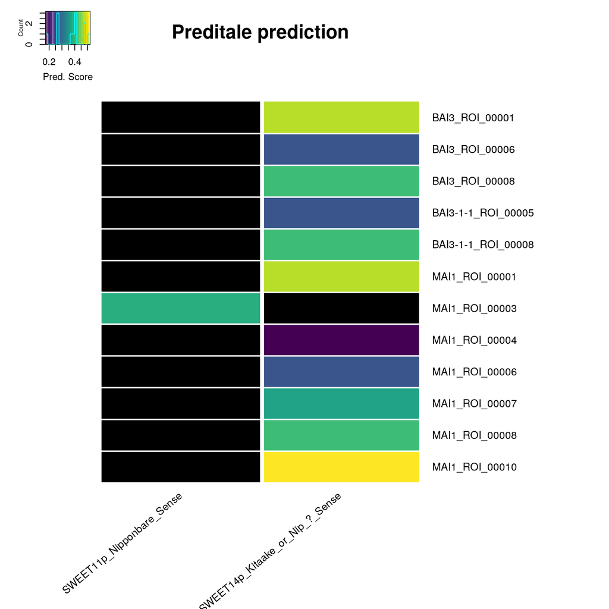

```r
talvezPreds$strain <- gsub("\\_.+", "", talvezPreds$taleId)
talvezPreds$group <- sapply(talvezPreds$taleId, function(id) {
  ifelse(id %in% taleGroups$name, taleGroups$group[taleGroups$name == id], NA)
}, USE.NAMES = F)

slctPromoters <- c("SWEET14p_Kitaake_or_Nip_?_Sense", "SWEET13p_Nipponbare_Sense", "SWEET11p_Nipponbare_Sense")
selectedPreds <- preditalePreds %>%
  dplyr::filter(subjSeqId %in% slctPromoters)

selectedPredsMat <- selectedPreds %>%
  reshape2::acast(taleId ~ subjSeqId, max, na.rm = TRUE, value.var = "score", fill = as.single(NA))

gplots::heatmap.2(selectedPredsMat,
                  col = viridis::viridis(20), #cm.colors(255),
                  sepwidth=c(0.02,0.02), sepcolor="white", colsep = 1:ncol(selectedPredsMat), rowsep = 1:nrow(selectedPredsMat),
                  trace="none",
                  margins = c(10, 15),
                  cexRow = 1,
                  cexCol = 1, srtCol = 40,
                  density.info= "histogram", key.xlab = "Pred. Score", key.title = NA,
                  lwid = c(1,5), lhei = c(1,5),
                  dendrogram = "none", Rowv = NULL, Colv = NULL,
                  na.color = "black",
                  main = "Preditale prediction"
                  )
```

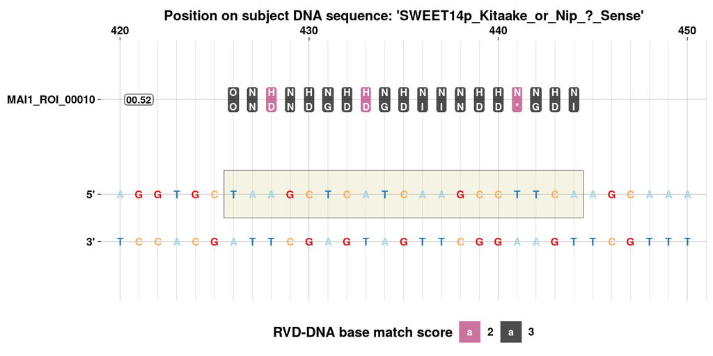

```r
grFilter <- "SWEET14p_Kitaake_or_Nip_?_Sense:420-450"
plotTaleTargetPred(predResults = selectedPreds, subjDnaSeqFile = subjDnaSeqFile, filterRange = grFilter)
```